# Google PlayStore Data Analysis

```r
library(tidyverse)
```

In this problem, we will explore the Google Play Store Apps Dataset, scraped from the Google Play Store. Each row in the table is an app. Here are descriptions of some of the columns.

1. Category Category the app belongs to
2. Rating Overall user rating of the app (as when scraped)
3. Reviews Number of user reviews for the app (as when scraped)
4. Installs Number of user downloads/installs for the app (as when scraped)

```r
df= read.csv("F://R Scripts//Data//googleplaystore.csv")
df
```

| App | Category | Rating | Reviews | Size | Installs | Type | Price | Content.Rating | Genres | Last.Updated | Current.Ver | Android.Ver |
| --- | --- | --- | --- | --- | --- | --- | --- | --- | --- | --- | --- | --- |
| Photo Editor & Candy Camera & Grid & ScrapBook | ART_AND_DESIGN | 4.1 | 159 | 19M | 10,000+ | Free | 0 | Everyone | Art & Design | January 7, 2018 | 1.0.0 | 4.0.3 and up |
| Coloring book moana | ART_AND_DESIGN | 3.9 | 967 | 14M | 500,000+ | Free | 0 | Everyone | Art & Design;Pretend Play | January 15, 2018 | 2.0.0 | 4.0.3 and up |
| U Launcher Lite â\200“ FREE Live Cool Themes, Hide Apps | ART_AND_DESIGN | 4.7 | 87510 | 8.7M | 5,000,000+ | Free | 0 | Everyone | Art & Design | August 1, 2018 | 1.2.4 | 4.0.3 and up |
| Sketch - Draw & Paint | ART_AND_DESIGN | 4.5 | 215644 | 25M | 50,000,000+ | Free | 0 | Teen | Art & Design | June 8, 2018 | Varies with device | 4.2 and up |
| Pixel Draw - Number Art Coloring Book | ART_AND_DESIGN | 4.3 | 967 | 2.8M | 100,000+ | Free | 0 | Everyone | Art & Design;Creativity | June 20, 2018 | 1.1 | 4.4 and up |
| Paper flowers instructions | ART_AND_DESIGN | 4.4 | 167 | 5.6M | 50,000+ | Free | 0 | Everyone | Art & Design | March 26, 2017 | 1.0 | 2.3 and up |
| Smoke Effect Photo Maker - Smoke Editor | ART_AND_DESIGN | 3.8 | 178 | 19M | 50,000+ | Free | 0 | Everyone | Art & Design | April 26, 2018 | 1.1 | 4.0.3 and up |
| Infinite Painter | ART_AND_DESIGN | 4.1 | 36815 | 29M | 1,000,000+ | Free | 0 | Everyone | Art & Design | June 14, 2018 | 6.1.61.1 | 4.2 and up |
| Garden Coloring Book | ART_AND_DESIGN | 4.4 | 13791 | 33M | 1,000,000+ | Free | 0 | Everyone | Art & Design | September 20, 2017 | 2.9.2 | 3.0 and up |
| Kids Paint Free - Drawing Fun | ART_AND_DESIGN | 4.7 | 121 | 3.1M | 10,000+ | Free | 0 | Everyone | Art & Design;Creativity | July 3, 2018 | 2.8 | 4.0.3 and up |

[output cut: 990 more lines]

### Question 1.

Assign by_content to a dataframe which counts the number of apps per Content Rating. List the Content Ratings alphabetically. Hint:You can use groupby

```r
by_content = df %>% group_by(Content.Rating) %>% summarise(count=n()) %>% arrange(Content.Rating)
by_content
```

| Content.Rating | count |
| --- | --- |
|  | 1 |
| Adults only 18+ | 3 |
| Everyone | 8714 |
| Everyone 10+ | 414 |
| Mature 17+ | 499 |
| Teen | 1208 |
| Unrated | 2 |

### Question 2.

Compute the number of apps in the dataset that have 1.5 stars or lower, and save the result in bad_apps and compute the number of apps in the dataset that have 4 stars or higher, and save the results in good_apps.

```r
bad_apps=df %>%  filter(Rating<=1.5)
bad_apps
```

| App | Category | Rating | Reviews | Size | Installs | Type | Price | Content.Rating | Genres | Last.Updated | Current.Ver | Android.Ver |
| --- | --- | --- | --- | --- | --- | --- | --- | --- | --- | --- | --- | --- |
| House party - live chat | DATING | 1.0 | 1 | 9.2M | 10+ | Free | 0 | Mature 17+ | Dating | July 31, 2018 | 3.52 | 4.0.3 and up |
| Speech Therapy: F | FAMILY | 1.0 | 1 | 16M | 10+ | Paid | $2.99 | Everyone | Education | October 7, 2016 | 1.0 | 2.3.3 and up |
| Clarksburg AH | MEDICAL | 1.0 | 1 | 28M | 50+ | Free | 0 | Everyone | Medical | May 1, 2017 | 300000.0.81 | 4.0.3 and up |
| Truck Driving Test Class 3 BC | FAMILY | 1.0 | 1 | 2.0M | 50+ | Paid | $1.49 | Everyone | Education | April 9, 2012 | 1.0 | 2.1 and up |
| BD Provider App | HEALTH_AND_FITNESS | 1.4 | 45 | 13M | 5,000+ | Free | 0 | Everyone | Health & Fitness | September 12, 2016 | 1.0 | 4.1 and up |
| BJ Bridge Standard American 2018 | GAME | 1.0 | 1 | 4.9M | 1,000+ | Free | 0 | Everyone | Card | May 21, 2018 | 6.2-sayc | 4.0 and up |
| MbH BM | MEDICAL | 1.0 | 1 | 2.3M | 100+ | Free | 0 | Everyone | Medical | December 14, 2016 | 1.1.3 | 4.3 and up |
| CB Mobile Access | FINANCE | 1.5 | 57 | 25M | 1,000+ | Free | 0 | Everyone | Finance | February 26, 2018 | 4.3.6 | 4.2 and up |
| CB Mobile Biz | FINANCE | 1.0 | 3 | 8.4M | 500+ | Free | 0 | Everyone | Finance | February 22, 2016 | 4.4.1255 | 4.0 and up |
| CF Climb | LIFESTYLE | 1.5 | 2 | 3.0M | 100+ | Free | 0 | Everyone | Lifestyle | June 7, 2018 | 3.9.9.2 | 2.3 and up |

[output cut: 13 more lines]

```r
cat("Count of bad apps is :",nrow(bad_apps))
```

```
Count of bad apps is : 23
```

```r
unique(bad_apps$App)
```

```
 [1] "House party - live chat"
 [2] "Speech Therapy: F"
 [3] "Clarksburg AH"
 [4] "Truck Driving Test Class 3 BC"
 [5] "BD Provider App"
 [6] "BJ Bridge Standard American 2018"
 [7] "MbH BM"
 [8] "CB Mobile Access"
 [9] "CB Mobile Biz"
[10] "CF Climb"
[11] "Thistletown CI"
[12] "CJ DVD Rentals"
[13] "Hercules CP Mobile"
[14] "CR Magazine"
[15] "Tech CU Card Manager"
[16] "Quiz DC"
[17] "DS Creator 2.0"
[18] "DT future1 cam"
[19] "EY TaxChat"
[20] "FE Mechanical Engineering Prep"
[21] "Familial Hypercholesterolaemia Handbook"
[22] "FK Atlantas"
[23] "Lottery Ticket Checker - Florida Results & Lotto"
```

```r
good_apps=df %>%  filter(Rating>=4)
good_apps
```

| App | Category | Rating | Reviews | Size | Installs | Type | Price | Content.Rating | Genres | Last.Updated | Current.Ver | Android.Ver |
| --- | --- | --- | --- | --- | --- | --- | --- | --- | --- | --- | --- | --- |
| Photo Editor & Candy Camera & Grid & ScrapBook | ART_AND_DESIGN | 4.1 | 159 | 19M | 10,000+ | Free | 0 | Everyone | Art & Design | January 7, 2018 | 1.0.0 | 4.0.3 and up |
| U Launcher Lite â\200“ FREE Live Cool Themes, Hide Apps | ART_AND_DESIGN | 4.7 | 87510 | 8.7M | 5,000,000+ | Free | 0 | Everyone | Art & Design | August 1, 2018 | 1.2.4 | 4.0.3 and up |
| Sketch - Draw & Paint | ART_AND_DESIGN | 4.5 | 215644 | 25M | 50,000,000+ | Free | 0 | Teen | Art & Design | June 8, 2018 | Varies with device | 4.2 and up |
| Pixel Draw - Number Art Coloring Book | ART_AND_DESIGN | 4.3 | 967 | 2.8M | 100,000+ | Free | 0 | Everyone | Art & Design;Creativity | June 20, 2018 | 1.1 | 4.4 and up |
| Paper flowers instructions | ART_AND_DESIGN | 4.4 | 167 | 5.6M | 50,000+ | Free | 0 | Everyone | Art & Design | March 26, 2017 | 1.0 | 2.3 and up |
| Infinite Painter | ART_AND_DESIGN | 4.1 | 36815 | 29M | 1,000,000+ | Free | 0 | Everyone | Art & Design | June 14, 2018 | 6.1.61.1 | 4.2 and up |
| Garden Coloring Book | ART_AND_DESIGN | 4.4 | 13791 | 33M | 1,000,000+ | Free | 0 | Everyone | Art & Design | September 20, 2017 | 2.9.2 | 3.0 and up |
| Kids Paint Free - Drawing Fun | ART_AND_DESIGN | 4.7 | 121 | 3.1M | 10,000+ | Free | 0 | Everyone | Art & Design;Creativity | July 3, 2018 | 2.8 | 4.0.3 and up |
| Text on Photo - Fonteee | ART_AND_DESIGN | 4.4 | 13880 | 28M | 1,000,000+ | Free | 0 | Everyone | Art & Design | October 27, 2017 | 1.0.4 | 4.1 and up |
| Name Art Photo Editor - Focus n Filters | ART_AND_DESIGN | 4.4 | 8788 | 12M | 1,000,000+ | Free | 0 | Everyone | Art & Design | July 31, 2018 | 1.0.15 | 4.0 and up |

[output cut: 990 more lines]

```r
cat("Count of Good apps is :",nrow(good_apps))
```

```
Count of Good apps is : 7369
```

### Question 3.

How many apps listed have the word “Google” (with that exact capitalization) in the App name? Save the number as google_apps. Note: each row is a separate App and should be counted as such (even if the names are the same)

```r
google_apps_df = df %>% filter(grepl("google|Google",App))
google_apps_df
```

| App | Category | Rating | Reviews | Size | Installs | Type | Price | Content.Rating | Genres | Last.Updated | Current.Ver | Android.Ver |
| --- | --- | --- | --- | --- | --- | --- | --- | --- | --- | --- | --- | --- |
| Google Play Books | BOOKS_AND_REFERENCE | 3.9 | 1433233 | Varies with device | 1,000,000,000+ | Free | 0 | Teen | Books & Reference | August 3, 2018 | Varies with device | Varies with device |
| Google My Business | BUSINESS | 4.4 | 70991 | Varies with device | 5,000,000+ | Free | 0 | Everyone | Business | July 24, 2018 | 2.19.0.204537701 | 4.4 and up |
| Google Primer | BUSINESS | 4.4 | 62272 | 18M | 10,000,000+ | Free | 0 | Everyone | Business | June 26, 2018 | 3.550.2 | 4.1 and up |
| Google Ads | BUSINESS | 4.3 | 29313 | 20M | 5,000,000+ | Free | 0 | Everyone | Business | July 30, 2018 | 1.12.0 | 4.0.3 and up |
| Google My Business | BUSINESS | 4.4 | 70991 | Varies with device | 5,000,000+ | Free | 0 | Everyone | Business | July 24, 2018 | 2.19.0.204537701 | 4.4 and up |
| Google Analytics | BUSINESS | 4.5 | 78662 | 22M | 1,000,000+ | Free | 0 | Everyone | Business | February 13, 2018 | 3.7.5 | 4.4 and up |
| Google Ads | BUSINESS | 4.3 | 29313 | 20M | 5,000,000+ | Free | 0 | Everyone | Business | July 30, 2018 | 1.12.0 | 4.0.3 and up |
| Google My Business | BUSINESS | 4.4 | 70991 | Varies with device | 5,000,000+ | Free | 0 | Everyone | Business | July 24, 2018 | 2.19.0.204537701 | 4.4 and up |
| Google Analytics | BUSINESS | 4.5 | 78662 | 22M | 1,000,000+ | Free | 0 | Everyone | Business | February 13, 2018 | 3.7.5 | 4.4 and up |
| Google Chrome: Fast & Secure | COMMUNICATION | 4.3 | 9642995 | Varies with device | 1,000,000,000+ | Free | 0 | Everyone | Communication | August 1, 2018 | Varies with device | Varies with device |

[output cut: 84 more lines]

```r
google_apps= nrow(google_apps_df)
cat("Number of Google Apps is :",google_apps)
```

```
Number of Google Apps is : 94
```

### Question 4.

Of the apps under the Category COMMUNICATION, get the Content Rating count for apps where the Rating is between or equal to 4 and 5 (inclusive). Return this as a table sorted by count (with greatest count at the top of the table) called top_communication_apps. Hint: creating two Dataframes may help. Even though it is possible to do this in one line, sometimes it’s better to break up the tasks to make the overall process clearer. We will only check the final table though.

```r
top_communication_apps = df %>% filter(Category=="COMMUNICATION" & Rating>=4 & Rating<=5) %>% group_by(Content.Rating) %>% summarise(Count=n()) %>% arrange(desc(Count))
top_communication_apps
```

| Content.Rating | Count |
| --- | --- |
| Everyone | 238 |
| Teen | 22 |
| Mature 17+ | 8 |

```r
df$Installs =gsub(",","",df$Installs)
df$Installs =as.numeric(gsub("[+]","",df$Installs))
str(df$Installs)
```

```
 num [1:10841] 1e+04 5e+05 5e+06 5e+07 1e+05 5e+04 5e+04 1e+06 1e+06 1e+04 ...
```

```r
install_stats = df %>% group_by(Content.Rating) %>% summarise(mean_installs=mean(Installs))
install_stats
```

| Content.Rating | mean_installs |
| --- | --- |
|  | NA |
| Adults only 18+ | 666666.7 |
| Everyone | 13100374.1 |
| Everyone 10+ | 31965898.1 |
| Mature 17+ | 11071124.6 |
| Teen | 28738700.7 |
| Unrated | 25250.0 |

### Question 6.

```r
best_category_df = df %>% filter(Rating>=4 & Installs >=1000000) %>% arrange(Installs)
best_category_df
```

| App | Category | Rating | Reviews | Size | Installs | Type | Price | Content.Rating | Genres | Last.Updated | Current.Ver | Android.Ver |
| --- | --- | --- | --- | --- | --- | --- | --- | --- | --- | --- | --- | --- |
| Infinite Painter | ART_AND_DESIGN | 4.1 | 36815 | 29M | 1e+06 | Free | 0 | Everyone | Art & Design | June 14, 2018 | 6.1.61.1 | 4.2 and up |
| Garden Coloring Book | ART_AND_DESIGN | 4.4 | 13791 | 33M | 1e+06 | Free | 0 | Everyone | Art & Design | September 20, 2017 | 2.9.2 | 3.0 and up |
| Text on Photo - Fonteee | ART_AND_DESIGN | 4.4 | 13880 | 28M | 1e+06 | Free | 0 | Everyone | Art & Design | October 27, 2017 | 1.0.4 | 4.1 and up |
| Name Art Photo Editor - Focus n Filters | ART_AND_DESIGN | 4.4 | 8788 | 12M | 1e+06 | Free | 0 | Everyone | Art & Design | July 31, 2018 | 1.0.15 | 4.0 and up |
| Real Tractor Farming | AUTO_AND_VEHICLES | 4.0 | 1598 | 56M | 1e+06 | Free | 0 | Everyone | Auto & Vehicles | July 26, 2018 | 11.0 | 4.1 and up |
| Used Cars and Trucks for Sale | AUTO_AND_VEHICLES | 4.6 | 17057 | Varies with device | 1e+06 | Free | 0 | Everyone | Auto & Vehicles | July 30, 2018 | Varies with device | Varies with device |
| ezETC (ETC balance inquiry, meter trial, real-time traffic) | AUTO_AND_VEHICLES | 4.3 | 38846 | 8.6M | 1e+06 | Free | 0 | Everyone | Auto & Vehicles | July 28, 2018 | 2.20 Build 02 | 4.1 and up |
| Police Detector (Speed Camera Radar) | AUTO_AND_VEHICLES | 4.3 | 3574 | 3.9M | 1e+06 | Free | 0 | Everyone 10+ | Auto & Vehicles | July 4, 2018 | 1.6 | 4.0 and up |
| Tickets + PDA 2018 Exam | AUTO_AND_VEHICLES | 4.9 | 197136 | 38M | 1e+06 | Free | 0 | Everyone | Auto & Vehicles | July 15, 2018 | 8.31 | 4.1 and up |
| PakWheels: Buy & Sell Cars | AUTO_AND_VEHICLES | 4.4 | 15168 | 37M | 1e+06 | Free | 0 | Everyone | Auto & Vehicles | July 27, 2018 | 10.0.2 | 4.2 and up |

[output cut: 990 more lines]

```r
best_category = unique(best_category_df$Category)
best_category
```

```
 [1] "ART_AND_DESIGN"      "AUTO_AND_VEHICLES"   "BEAUTY"
 [4] "BOOKS_AND_REFERENCE" "BUSINESS"            "COMICS"
 [7] "COMMUNICATION"       "DATING"              "EDUCATION"
[10] "ENTERTAINMENT"       "EVENTS"              "FINANCE"
[13] "FOOD_AND_DRINK"      "HEALTH_AND_FITNESS"  "HOUSE_AND_HOME"
[16] "LIBRARIES_AND_DEMO"  "LIFESTYLE"           "GAME"
[19] "FAMILY"              "MEDICAL"             "SOCIAL"
[22] "SHOPPING"            "PHOTOGRAPHY"         "SPORTS"
[25] "TRAVEL_AND_LOCAL"    "TOOLS"               "PERSONALIZATION"
[28] "PRODUCTIVITY"        "PARENTING"           "WEATHER"
[31] "VIDEO_PLAYERS"       "NEWS_AND_MAGAZINES"  "MAPS_AND_NAVIGATION"
```

### Question 7.

Make a bar chart of the average rating by category in which the bars are sorted from smallest to largest

```r
data= df %>% group_by(Category) %>% summarise(average_rating=mean(Rating,na.rm=TRUE)) %>% arrange(average_rating)
data
```

| Category | average_rating |
| --- | --- |
| DATING | 3.970769 |
| TOOLS | 4.047411 |
| MAPS_AND_NAVIGATION | 4.051613 |
| VIDEO_PLAYERS | 4.063750 |
| LIFESTYLE | 4.094904 |
| TRAVEL_AND_LOCAL | 4.109292 |
| BUSINESS | 4.121452 |
| ENTERTAINMENT | 4.126174 |
| FINANCE | 4.131889 |
| NEWS_AND_MAGAZINES | 4.132189 |

[output cut: 24 more lines]

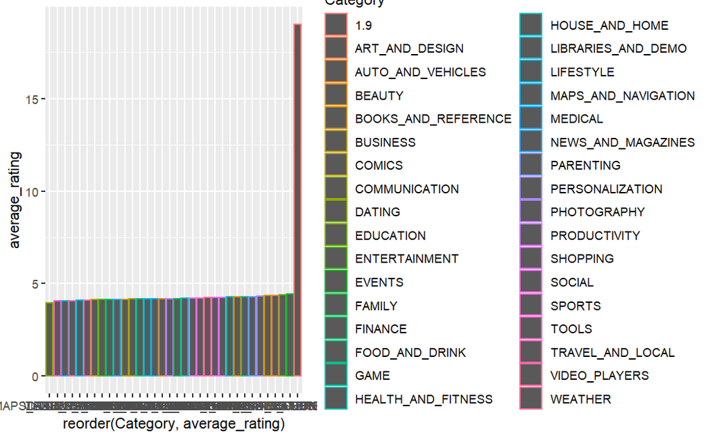

```r
ggplot(data,aes(x=reorder(Category,average_rating),y=average_rating,color=Category)) + geom_bar(stat="identity")
```